# Comparison of Tissues

Bryon Drown

January 10, 2022

# TODO

Bryon’s todo list:

- GSEA analysis across separation tech
- Plot number of proteoforms per protein by each method
- List top proteins by number of proteoforms

A hit report was generated by TDviewer. The Hit Report includes many hits that correspond to PFRs that didn’t pass the protein-level FDR cutoff. My solution is to export the list of PFRs on the Proteoform tab of TDviewer and use this list to filter the Hit Report.

```r
load("preprocessed.RData")
```

# QC of acquisitions

I used RawTools 2.0.3 (https://github.com/kevinkovalchik/RawTools) to analyze the raw files.

```r
# Get the metrics that were generated by RawTools
metric_files <- list.files(path = "rawtools", pattern = "_Metrics.txt", full.names = TRUE)

metric_list <- lapply(metric_files, function(i){
  header <- c("RawFile", "Instrument", "ExperimentMsOrder", "MS1Analyzer", "MS2Analyzer", "MS3Analyzer", "TotalAnalysisTime", "TotalScans",
              "NumMs1Scans", "NumMs2Scans", "NumMs3Scans", "MeanMs2TriggerRate", "Ms1ScanRate", "Ms2ScanRate", "MeanDutyCycle", "MedianMs1FillTime",
              "MedianMs2FillTime", "MedianMs3FillTime", "Ms2MedianSummedIntensity", "MedianMS1IsolationInterference", "MedianPeakWidthAt10pcH",
              "MedianPeakWidthAt50pcH", "MedianAsymmetryFactor", "PeakCapacity", "NumEsiInstabilityFlags")
  x <- read.csv(i, header = FALSE, sep = "\t")
  x <- t(x)
  colnames(x) <- header
  x[2,]
})
metrics <- bind_rows(metric_list)

metrics[,7:25] <- lapply(metrics[,7:25], function(x) as.numeric(as.character(x)))
# Parse the rawfile names
metrics <- metrics %>%
  separate(col = RawFile, into = c('Front', 'NetId', 'Project', 'Separation', 'Tissue', 'Biorep', 'Fraction', 'Injection'),
           extra = "drop", convert = TRUE, sep = "_") %>%
  select(-Front)

metrics <- metrics %>%
  mutate(TissueSep = paste0(Tissue, " - ", Separation))
```

```r
plot <- ggplot(metrics, aes(x = MeanMs2TriggerRate,y = TissueSep, fill = TissueSep)) +
  geom_boxplot() +
  labs(x = "Mean MS2 Trigger Rate (MS2 scans per MS1 scan)") +
  theme_bw() +
  theme(legend.position = "none")
plot
pdf(file = "figures/RawTools_MS2_Trigger_Rate.pdf", width = 7, height = 5)
```

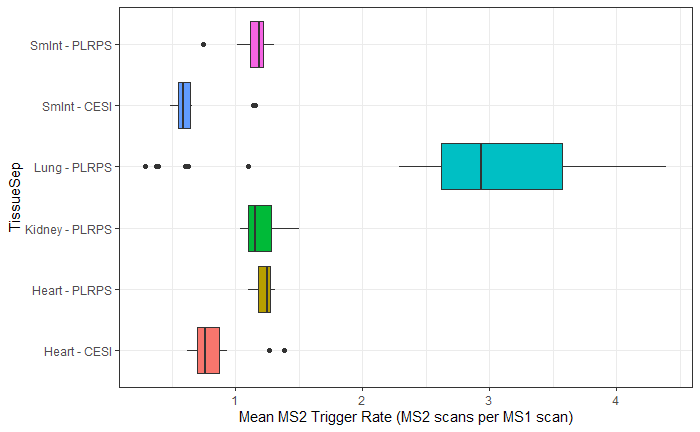

```r
print(plot)
dev.off()
```

```r
plot <- ggplot(metrics, aes(x = NumMs2Scans,y = TissueSep, fill = TissueSep)) +
  geom_boxplot() +
  labs(x = "Number of MS2 Scans") +
  theme_bw() +
  theme(legend.position = "none")
plot
pdf(file = "figures/RawTools_Num_MS2.pdf", width = 7, height = 5)
```

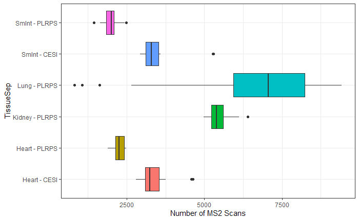

```r
print(plot)
dev.off()
```

```r
plot <- ggplot(metrics, aes(x = Ms2MedianSummedIntensity,y = TissueSep, fill = TissueSep)) +
  geom_boxplot() +
  labs(x = "Median MS2 Intensity") +
  theme_bw() +
  theme(legend.position = "none")
plot
pdf(file = "figures/RawTools_MS2_Intensity.pdf", width = 7, height = 5)
```

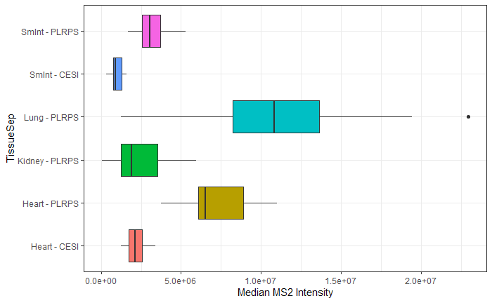

```r
print(plot)
dev.off()
```

```r
plot <- ggplot(metrics, aes(x = NumEsiInstabilityFlags,y = TissueSep, fill =TissueSep)) +
  geom_boxplot() +
  labs(x = "Number ESI Instability Flags") +
  theme_bw() +
  theme(legend.position = "none")
plot
pdf(file = "figures/RawTools_ESI_Instability.pdf", width = 7, height = 5)
```

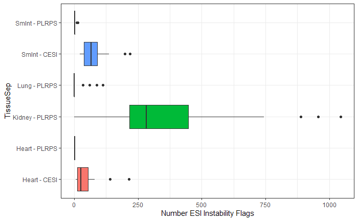

```r
print(plot)
dev.off()
```

```r
plot <- ggplot(metrics, aes(x = MedianMs2FillTime,y = TissueSep, fill = TissueSep)) +
  geom_boxplot() +
  labs(x = "Median Ms2 Fill Time (ms)") +
  theme_bw() +
  theme(legend.position = "none")
plot
pdf(file = "figures/RawTools_MS2_Fill_Time.pdf", width = 7, height = 5)
```

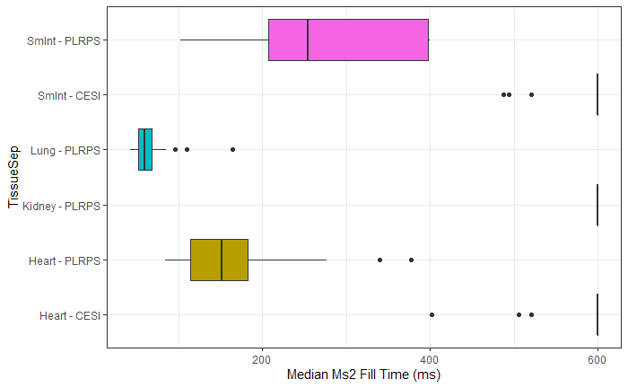

```r
print(plot)
dev.off()
```

```r
plot <- ggplot(metrics, aes(x = MedianMs1FillTime,y = TissueSep, fill = TissueSep)) +
  geom_boxplot() +
  labs(x = "Median Ms1 Fill Time (ms)") +
  theme_bw() +
  theme(legend.position = "none")
plot
pdf(file = "figures/RawTools_MS1_Fill_Time.pdf", width = 7, height = 5)
```

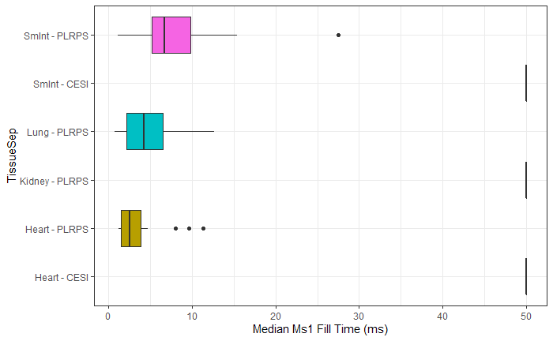

```r
print(plot)
dev.off()
```

# Top Proteins overall

## Proteoforms per Protein

```r
# First count the number of proteoforms
pfr_count <- hits %>%
  select(PFR, Uniprot_Id, Tissue) %>%
  unique() %>%
  group_by(Uniprot_Id, Tissue) %>%
  summarise(Count = n(), .groups = "drop")

# Which protein entries have the most proteoforms?
pfr_count %>%
  arrange(-Count) %>%
  pivot_wider(names_from = "Tissue", values_from = "Count")
```

| Uniprot_Id | Lung | Kidney | Spleen | SmInt | Heart |
| --- | --- | --- | --- | --- | --- |
| HBB_HUMAN | 2676 | 1122 | 594 | 62 | 297 |
| H33_HUMAN | 79 | 1 | 13 | 522 | 369 |
| H31_HUMAN | 36 | NA | 34 | 473 | 38 |
| H32_HUMAN | 27 | NA | 3 | 330 | 50 |
| HBA_HUMAN | 319 | 181 | 151 | 13 | 52 |
| H4_HUMAN | 188 | 10 | 70 | 124 | 61 |
| ACTB_HUMAN | 68 | NA | 158 | 30 | NA |
| MLRV_HUMAN | NA | NA | NA | 1 | 141 |
| HSPB1_HUMAN | 7 | 1 | NA | 9 | 130 |
| TNNT2_HUMAN | NA | NA | NA | NA | 100 |

[output cut: 730 more lines]

There are no big surprises for which proteins are more frequently characterized

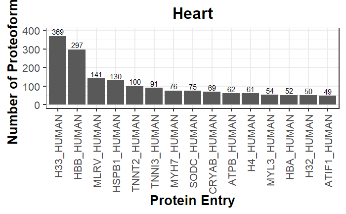

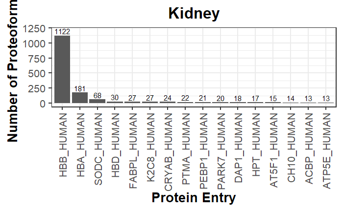

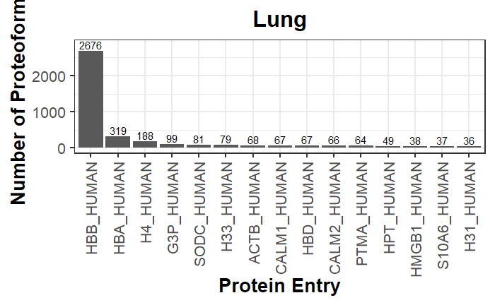

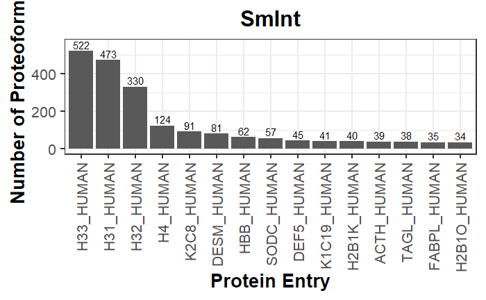

```r
plots <- pfr_count %>%
  group_by(Tissue) %>%
  slice_max(n = 15, Count) %>%
  do(plots = ggplot(data=.) +
       aes(x = reorder(Uniprot_Id,-Count), y = Count, label = Count) +
       geom_col() +
       geom_text(aes(y = Count + max(Count)/15)) +
       labs(title = unique(.$Tissue),
            x = "Protein Entry",
            y = "Number of Proteoforms") +
       theme_bw(base_size = 20) +
       theme(axis.text.x = element_text(angle = 90, vjust = 0.5, hjust=1),
             plot.title = element_text(face = "bold", hjust = 0.5),
             axis.title = element_text(face = "bold"))
     )
plots[[2]]
```

```r
pdf("figures/PFRCounts_byProtein.pdf", height = 6, width = 7)
plots[[2]]
```

[figure not shown]

```r
dev.off()
```

# Unique proteoforms/proteins

## Table of unique proteoforms

For the manuscript, we need a table that describes how many proteoforms match certain criteria

```r
# Table 1 ======================================================================
# For the manuscript, we need a table that describes how many proteoforms match
# certain criteria

# Overall counts ###############################################################
# Proteins
df <- hits %>%
  select(HitId, PFR, Uniprot_Id, Tissue, Global_Q.value, C.score, E.value) %>%
  group_by(PFR, Tissue) %>%
  slice_min(Global_Q.value) %>% # get the best hit for each proteoform in each tissue
  slice_min(E.value) %>% # sometimes there are ties for Q.value so this breaks ties
  slice_max(C.score) %>%
  ungroup() %>%
  unique()

x <- df %>%
  select(Tissue, Uniprot_Id) %>%
  unique() %>%
  group_by(Tissue) %>%
  summarise(Protein_Total = n())
print("Number of Proteins ID overall:")
```

```
[1] "Number of Proteins ID overall:"
```

```r
x
```

| Tissue | Protein_Total |
| --- | --- |
| Heart | 305 |
| Kidney | 307 |
| Lung | 437 |
| SmInt | 305 |
| Spleen | 213 |

```r
sum(x$Protein_Total)
```

```
[1] 1567
```

```r
# Unique proteins
proteins <- df %>%
  select(Tissue, Uniprot_Id) %>%
  unique() %>%
  group_by(Uniprot_Id) %>%
  summarise(Num_Tissues = n())

x <- df %>%
  merge(proteins) %>%
  select(Tissue, Uniprot_Id, Num_Tissues) %>%
  filter(Num_Tissues == 1) %>%
  unique() %>%
  group_by(Tissue) %>%
  summarise(Protein_Unique = n())
print("Number of Unique Proteins ID overall:")
```

```
[1] "Number of Unique Proteins ID overall:"
```

```r
x
```

| Tissue | Protein_Unique |
| --- | --- |
| Heart | 70 |
| Kidney | 62 |
| Lung | 132 |
| SmInt | 43 |
| Spleen | 36 |

```r
sum(x$Protein_Unique)
```

```
[1] 343
```

```r
# Proteoforms
# Total
x <- df %>%
  select(Tissue, PFR) %>%
  unique() %>%
  group_by(Tissue) %>%
  summarise(Proteoform_Total = n())
print("Number of Proteoform IDs overall:")
```

```
[1] "Number of Proteoform IDs overall:"
```

```r
x
```

| Tissue | Proteoform_Total |
| --- | --- |
| Heart | 2897 |
| Kidney | 2278 |
| Lung | 5566 |
| SmInt | 3101 |
| Spleen | 1869 |

```r
sum(x$Proteoform_Total)
```

```
[1] 15711
```

```r
# Total characterized
x <- df %>%
  select(Tissue, PFR, C.score) %>%
  filter(C.score >= 30) %>%
  unique() %>%
  group_by(Tissue) %>%
  summarise(Proteoform_Total_Char = n())
print("Number of Characterized Proteoform IDs overall:")
```

```
[1] "Number of Characterized Proteoform IDs overall:"
```

```r
x
```

| Tissue | Proteoform_Total_Char |
| --- | --- |
| Heart | 1264 |
| Kidney | 877 |
| Lung | 2143 |
| SmInt | 1114 |
| Spleen | 959 |

```r
sum(x$Proteoform_Total_Char)
```

```
[1] 6357
```

```r
# Unique proteoforms
proteoforms <- df %>%
  select(Tissue, PFR) %>%
  unique() %>%
  group_by(PFR) %>%
  summarise(Num_Tissues = n())

x <- df %>%
  merge(proteoforms) %>%
  select(Tissue, PFR, Num_Tissues) %>%
  filter(Num_Tissues == 1) %>%
  unique() %>%
  group_by(Tissue) %>%
  summarise(Proteoform_Unique = n())
print("Number of Unique Proteoform IDs overall:")
```

```
[1] "Number of Unique Proteoform IDs overall:"
```

```r
x
```

| Tissue | Proteoform_Unique |
| --- | --- |
| Heart | 1623 |
| Kidney | 641 |
| Lung | 3601 |
| SmInt | 2049 |
| Spleen | 870 |

```r
sum(x$Proteoform_Unique)
```

```
[1] 8784
```

```r
# Unique characterized
x <- df %>%
  merge(proteoforms) %>%
  #select(Tissue, PFR, Num_Tissues, C.score) %>%
  filter(Num_Tissues == 1) %>%
  filter(C.score >= 30) %>%
  select(Tissue, PFR) %>%
  unique() %>%
  group_by(Tissue) %>%
  summarise(Proteoform_Unique_Char = n())
print("Number of Unique Characterized Proteoform IDs overall:")
```

```
[1] "Number of Unique Characterized Proteoform IDs overall:"
```

```r
x
```

| Tissue | Proteoform_Unique_Char |
| --- | --- |
| Heart | 772 |
| Kidney | 306 |
| Lung | 1462 |
| SmInt | 643 |
| Spleen | 589 |

```r
sum(x$Proteoform_Unique_Char)
```

```
[1] 3772
```

```r
# Non-redundant counts #########################################################
# Proteins
print("Non-redundant proteins overall:")
```

```
[1] "Non-redundant proteins overall:"
```

```r
df %>%
  select(Uniprot_Id) %>%
  unique() %>%
  nrow()
```

```
[1] 740
```

```r
# Proteoforms
print("Non-redundant proteoforms overall:")
```

```
[1] "Non-redundant proteoforms overall:"
```

```r
df %>%
  select(PFR) %>%
  unique() %>%
  nrow()
```

```
[1] 11466
```

```r
# Characterized proteoforms
print("Non-redundant characterized proteoforms overall:")
```

```
[1] "Non-redundant characterized proteoforms overall:"
```

```r
df %>%
  filter(C.score >= 30) %>%
  select(PFR) %>%
  unique() %>%
  nrow()
```

```
[1] 4874
```

```r
# Tissue-specific Proteoforms --------------------------------------------------

# We want high-confidence hits
df <- hits %>%
  group_by(PFR, Tissue) %>%
  slice_min(Global_Q.value) %>% # get the best hit for each proteoform in each tissue
  slice_min(E.value) %>% # sometimes there are ties for Q.value so this breaks ties
  slice_max(C.score) %>%
  ungroup() %>%
  filter(C.score >= 30) %>%
  filter(num_fragments >= ifelse(varied | modified, 3, 0))# if the proteoform is modified or contains a sequence variance, then there should be at least 3 supporting fragments

# Count the number of tissues each proteoform was observed in
proteoforms <- df %>%
  select(Tissue, PFR) %>%
  unique() %>%
  group_by(PFR) %>%
  summarise(Num_Tissues = n())

# Select the proteoforms observed in only one tissue and prepare for export
x <- df %>%
  merge(proteoforms) %>%
  arrange(Global_Q.value) %>%
  select(Tissue, PFR, Uniprot_Id, Accession, Description, P.score, E.value, Global_Q.value, C.score, Proteoform_Level, Result_Set, Num_Tissues, varied, modified, num_fragments) %>%
  filter(Num_Tissues == 1) %>%
  select(-Num_Tissues) %>%
  unique()

# For each tissue, write out the list of uniprot ids
x %>%
  write_tsv(file = "output_data/unique_pfr_all.tsv")

x %>%
  filter(Tissue == "Heart") %>%
  write_tsv(file = "output_data/unique_pfr_heart.tsv")

x %>%
  filter(Tissue == "Lung") %>%
  write_tsv(file = "output_data/unique_pfr_lung.tsv")

x %>%
  filter(Tissue == "Spleen") %>%
  write_tsv(file = "output_data/unique_pfr_spleen.tsv")

x %>%
  filter(Tissue == "Kidney") %>%
  write_tsv(file = "output_data/unique_pfr_kidney.tsv")

x %>%
  filter(Tissue == "SmInt") %>%
  write_tsv(file = "output_data/unique_pfr_smint.tsv")

# These tsv files are used to build the xlsx file that is included in the
# supplemental materials

x %>%
  filter(Result_Set == "Tight Absolute Mass") %>%
  group_by(Tissue) %>%
  summarise(AbsoluteMass_PFRs = n())
```

| Tissue | AbsoluteMass_PFRs |
| --- | --- |
| Heart | 111 |
| Kidney | 46 |
| Lung | 62 |
| SmInt | 56 |
| Spleen | 20 |

```r
x %>%
  filter(Result_Set == "BioMarker") %>%
  group_by(Tissue) %>%
  summarise(BioMarker_PFRs = n())
```

| Tissue | BioMarker_PFRs |
| --- | --- |
| Heart | 473 |
| Kidney | 163 |
| Lung | 875 |
| SmInt | 501 |
| Spleen | 536 |

```r
NA
```

```r
# How many unique proteoforms were identified in each tissue?
x %>%
  group_by(Tissue) %>%
  summarise(PFRs = n())
```

| Tissue | PFRs |
| --- | --- |
| Heart | 584 |
| Kidney | 209 |
| Lung | 937 |
| SmInt | 557 |
| Spleen | 556 |

```r
x %>%
  filter(Result_Set == "BioMarker") %>%
  group_by(Tissue) %>%
  summarise(PFRs = n())
```

| Tissue | PFRs |
| --- | --- |
| Heart | 473 |
| Kidney | 163 |
| Lung | 875 |
| SmInt | 501 |
| Spleen | 536 |

```r
x %>%
  filter(Result_Set == "Tight Absolute Mass") %>%
  group_by(Tissue) %>%
  summarise(PFRs = n())
```

| Tissue | PFRs |
| --- | --- |
| Heart | 111 |
| Kidney | 46 |
| Lung | 62 |
| SmInt | 56 |
| Spleen | 20 |

```r
# How many proteins are those proteoforms associated with?
y <- x %>%
  select(Uniprot_Id, Tissue) %>%
  unique()

y %>%
  group_by(Tissue) %>%
  summarise(Proteins = n())
```

| Tissue | Proteins |
| --- | --- |
| Heart | 146 |
| Kidney | 126 |
| Lung | 293 |
| SmInt | 131 |
| Spleen | 126 |

```r
# Proteins associated with biomarker proteoform hits
y <- x %>%
  filter(Result_Set == "BioMarker") %>%
  select(Uniprot_Id, Tissue) %>%
  unique()

y %>%
  group_by(Tissue) %>%
  summarise(Proteins = n())
```

| Tissue | Proteins |
| --- | --- |
| Heart | 90 |
| Kidney | 94 |
| Lung | 267 |
| SmInt | 98 |
| Spleen | 118 |

```r
# Proteins associated with tight absolute mass hits
y <- x %>%
  filter(Result_Set == "Tight Absolute Mass") %>%
  select(Uniprot_Id, Tissue) %>%
  unique()

y %>%
  group_by(Tissue) %>%
  summarise(Proteins = n())
```

| Tissue | Proteins |
| --- | --- |
| Heart | 86 |
| Kidney | 41 |
| Lung | 48 |
| SmInt | 49 |
| Spleen | 14 |

Histones and hemoglobin have the highest rate of proteoform annotation. We also wanted to generate unique proteoform lists that exclude histones and hemoglobin.

```r
# Unique proteoforms excluding histone and hemoglobin --------------------------
# TDportal uses a curated list of histones. This is the list of accessions I
# got from Ryan Fellers.
histones <- read_csv(file = "data/Histones_Accessions_v5_BSD.txt", col_names = c("Accession"))
# While hemoglobin alpha and beta are the most frequently observed isoforms,
# I'm just including all of them.
hemoglobins <- data.frame(Accession = c("P69905", "P68871", "P69891", "P69892", "P02042"))

df <- hits %>%
  filter(!Accession %in% histones$Accession) %>%
  filter(!Accession %in% hemoglobins$Accession) %>%
  group_by(PFR, Tissue) %>%
  slice_min(Global_Q.value) %>% # get the best hit for each proteoform in each tissue
  slice_min(E.value) %>% # sometimes there are ties for Q.value so this breaks ties
  slice_max(C.score) %>%
  ungroup() %>%
  filter(C.score >= 30) %>%
  filter(num_fragments >= ifelse(varied | modified, 3, 0))# if the proteoform is modified or contains a sequence variance, then there should be at least 3 supporting fragments


proteoforms <- df %>%
  select(Tissue, PFR) %>%
  unique() %>%
  group_by(PFR) %>%
  summarise(Num_Tissues = n())

x <- df %>%
  merge(proteoforms) %>%
  arrange(Global_Q.value) %>%
  select(Tissue, PFR, Uniprot_Id, Accession, Description, P.score, E.value, Global_Q.value, C.score, Proteoform_Level, Result_Set, Num_Tissues, varied, modified, num_fragments) %>%
  filter(Num_Tissues == 1) %>%
  select(-Num_Tissues) %>%
  unique()

# For each tissue, write out the list of uniprot ids
x %>%
  write_tsv(file = "output_data/unique_pfr_all_noHH.tsv")

x %>%
  filter(Tissue == "Heart") %>%
  write_tsv(file = "output_data/unique_pfr_heart_noHH.tsv")

x %>%
  filter(Tissue == "Lung") %>%
  write_tsv(file = "output_data/unique_pfr_lung_noHH.tsv")

x %>%
  filter(Tissue == "Spleen") %>%
  write_tsv(file = "output_data/unique_pfr_spleen_noHH.tsv")

x %>%
  filter(Tissue == "Kidney") %>%
  write_tsv(file = "output_data/unique_pfr_kidney_noHH.tsv")

x %>%
  filter(Tissue == "SmInt") %>%
  write_tsv(file = "output_data/unique_pfr_smint_noHH.tsv")

# How many unique proteoforms were identified in each tissue?
x %>%
  group_by(Tissue) %>%
  summarise(PFRs = n())
```

| Tissue | PFRs |
| --- | --- |
| Heart | 557 |
| Kidney | 183 |
| Lung | 748 |
| SmInt | 456 |
| Spleen | 377 |

```r
x %>%
  filter(Result_Set == "BioMarker") %>%
  group_by(Tissue) %>%
  summarise(PFRs = n())
```

| Tissue | PFRs |
| --- | --- |
| Heart | 455 |
| Kidney | 137 |
| Lung | 690 |
| SmInt | 405 |
| Spleen | 360 |

```r
# How many proteins are those proteoforms associated with?
y <- x %>%
  select(Uniprot_Id, Tissue) %>%
  unique()

y %>%
  group_by(Tissue) %>%
  summarise(Proteins = n())
```

| Tissue | Proteins |
| --- | --- |
| Heart | 135 |
| Kidney | 121 |
| Lung | 271 |
| SmInt | 110 |
| Spleen | 105 |

```r
y <- x %>%
  filter(Result_Set == "BioMarker") %>%
  select(Uniprot_Id, Tissue) %>%
  unique()

y %>%
  group_by(Tissue) %>%
  summarise(Proteins = n())
```

| Tissue | Proteins |
| --- | --- |
| Heart | 83 |
| Kidney | 89 |
| Lung | 247 |
| SmInt | 78 |
| Spleen | 98 |

```r
NA
```

## Comparison to Human Proteoform Atlas

Many of the proteoforms discovered in this initiative were actually rediscoveries judging by the PFR accession numbers assigned by TDportal.

I asked Mike to query the HPfA database and determine if the PFRs that we found here are a part of any dataset registered in HPfA. He sent a table back with them.

```r
hpfa <- read.csv("data/PFRs_HPfA.txt", sep = "\t")
#ctdp <- read.csv("data/ctdp_proteoforms.csv", sep=",") %>% mutate(In.CTDP = TRUE)

df <- hits %>%
  merge(hpfa, by = "PFR", all.x = TRUE) %>%
  select(PFR, Uniprot_Id, In.HPfA) %>%
  unique() %>%
  mutate(In.HPfA = ifelse(is.na(In.HPfA), FALSE, In.HPfA)) %>%
  mutate(Dataset = ifelse(In.HPfA, "HPfA", "New"))

hpfa.dataset <-  df %>%
  filter(In.HPfA) %>%
  select(PFR, Uniprot_Id) %>% unique()
write(hpfa.dataset$PFR, "output_data/pfr_HPfA.txt", ncolumns = 1)
write(hpfa.dataset$Uniprot_Id, "output_data/protein_hpfa.txt", ncolumns = 1)

all.datasets <- df %>%
  select(PFR, Uniprot_Id) %>% unique()
write(all.datasets$PFR, "output_data/pfr_all.txt", ncolumns = 1)
write(all.datasets$Uniprot_Id, "output_data/protein_all.txt", ncolumns = 1)


plt <- venn.diagram(
  x = list(hpfa.dataset$PFR, all.datasets$PFR),
  category.names = c("HPfA", "New"),
  filename = NULL,

  # Title
  main = "Proteoforms in Existing Databases",
  main.cex = 1.5,
  main.fontface = "bold",
  main.fontfamily = "sans",

  col=c("#d95f02","#7570b3"),
  fill = c(alpha('#d95f02',0.3), alpha('#7570b3',0.3)),
  cex = 2,
  fontfamily = "sans",
  cat.cex = 2,
  cat.default.pos = "outer",
  cat.pos = c(0, 80),
  cat.dist = c(0.03, -0.03),
  cat.fontfamily = "sans",
  cat.col = c("#d95f02","#7570b3")
)
ggsave(plt, file = "figures/Dataset_PFR_Venn_all.pdf", device = "pdf")
plt <- venn.diagram(
  x = list(hpfa.dataset$Uniprot_Id, all.datasets$Uniprot_Id),
  category.names = c("HPfA", "New"),
  filename = NULL,

  # Title
  main = "Proteins in Existing Databases",
  main.cex = 1.5,
  main.fontface = "bold",
  main.fontfamily = "sans",

  col=c("#d95f02","#7570b3"),
  fill = c(alpha('#d95f02',0.3), alpha('#7570b3',0.3)),
  cex = 2,
  fontfamily = "sans",
  cat.cex = 2,
  cat.default.pos = "outer",
  cat.pos = c(0, 80),
  cat.dist = c(0.03, -0.03),
  cat.fontfamily = "sans",
  cat.col = c("#d95f02","#7570b3")
)
ggsave(plt, file = "figures/Dataset_Protein_Venn_all.pdf", device = "pdf")
# All PFRs

data <- df %>%
  select(PFR, Dataset) %>%
  unique() %>%
  group_by(Dataset) %>%
  summarise(value = n())

data <- data %>%
  arrange(desc(Dataset)) %>%
  mutate(prop = value / sum(data$value) *100) %>%
  mutate(ypos = cumsum(prop)- 0.5*prop )
data
```

| Dataset | value | prop | ypos |
| --- | --- | --- | --- |
| New | 7373 | 64.30316 | 32.15158 |
| HPfA | 4093 | 35.69684 | 82.15158 |

```r
# Basic piechart
plot <- ggplot(data, aes(x="", y=prop, fill=Dataset)) +
  geom_bar(stat="identity", width=1, color="white") +
  coord_polar("y", start=0) +
  theme_void() +
  scale_fill_brewer(palette="Set1")
plot
pdf(file = "figures/Dataset_PFR_Piechart_all.pdf", width = 5, height = 5)
```

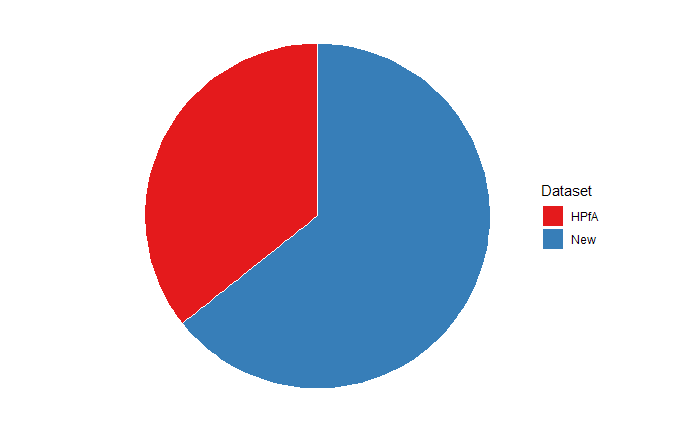

```r
print(plot)
dev.off()
```

```r
## Proteins
data <- df %>%
  select(PFR, Uniprot_Id, In.HPfA) %>%
  unique() %>%
  group_by(Uniprot_Id) %>%
  mutate(Dataset = ifelse(TRUE %in% In.HPfA, "HPfA", "New")) %>%
  ungroup() %>%
  select(Uniprot_Id, Dataset) %>%
  unique() %>%
  group_by(Dataset) %>%
  summarise(value = n())

data <- data %>%
  arrange(desc(Dataset)) %>%
  mutate(prop = value / sum(data$value) *100) %>%
  mutate(ypos = cumsum(prop)- 0.5*prop )
data
```

| Dataset | value | prop | ypos |
| --- | --- | --- | --- |
| New | 198 | 26.75676 | 13.37838 |
| HPfA | 542 | 73.24324 | 63.37838 |

```r
plot <- ggplot(data, aes(x="", y=prop, fill=Dataset)) +
  geom_bar(stat="identity", width=1, color="white") +
  coord_polar("y", start=0) +
  theme_void() +
  scale_fill_brewer(palette="Set1")
plot
pdf(file = "figures/Dataset_Protein_Piechart_all.pdf", width = 5, height = 5)
```

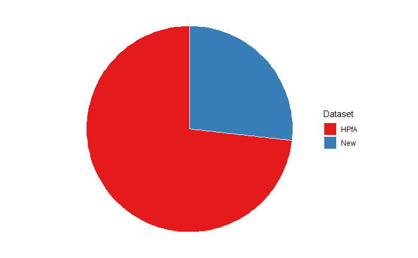

```r
print(plot)
dev.off()
```

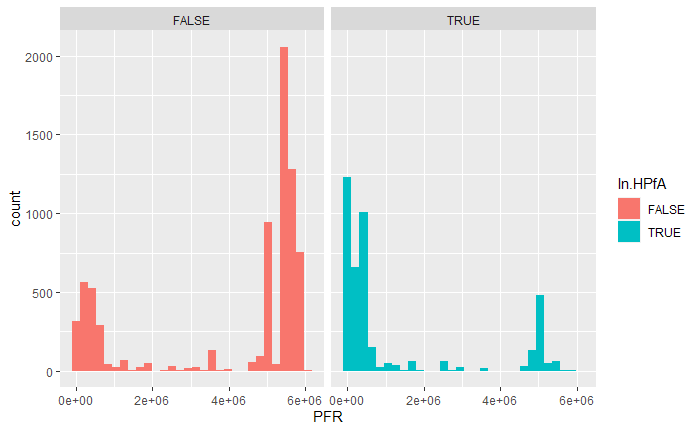

```r
# Histograms

df %>%
  select(PFR, In.HPfA) %>%
  unique() %>%
  ggplot(aes(x = PFR, fill = In.HPfA)) +
    geom_histogram() +
    facet_grid(~In.HPfA)
```

## Venn Diagrams

### Proteoform-level

```r
venn.pfr <- hits %>%
  select(PFR, Tissue) %>%
  unique() %>%
  arrange(PFR)

heart <- filter(venn.pfr, Tissue == "Heart")$PFR
smint <- filter(venn.pfr, Tissue == "SmInt")$PFR
lung <- filter(venn.pfr, Tissue == "Lung")$PFR
kidney <- filter(venn.pfr, Tissue == "Kidney")$PFR
spleen <- filter(venn.pfr, Tissue == "Spleen")$PFR

# Save the lists to files so that external programs can access them too
write(heart, "output_data/pfr_heart.txt", ncolumns = 1)
write(smint, "output_data/pfr_smint.txt", ncolumns = 1)
write(lung, "output_data/pfr_lung.txt", ncolumns = 1)
write(kidney, "output_data/pfr_kidney.txt", ncolumns = 1)
write(spleen, "output_data/pfr_spleen.txt", ncolumns = 1)

plt <- venn.diagram(
  x = list(heart, smint, lung, kidney, spleen),
  category.names = c("Heart", "Intestine", "Lung", "Kidney", "Spleen"),
  filename = "figures/tissue_pfr_venn.tiff",

  # Title
  main = "Proteoforms Identified in Tissues",
  main.cex = 2,
  main.fontface = "bold",
  main.fontfamily = "sans",

  # Colors
  col=c('#1b9e77','#d95f02','#7570b3','#e7298a','#66a61e'),
  fill = c(alpha('#1b9e77', 0.3), alpha('#d95f02', 0.3), alpha('#7570b3', 0.3), alpha('#e7298a', 0.3), alpha('#66a61e', 0.3)),
  #fill = c(alpha("#440154ff",0.3), alpha('#21908dff',0.3)),
  cat.col=c('#1b9e77','#d95f02','#7570b3','#e7298a','#66a61e'),

  # Numbers
  cex = 1.3,
  fontface = "bold",
  fontfamily = "sans",
  cat.pos = c(-60,-10,-80,190,10),
  cat.dist = c(0.25, 0.25, 0.3, 0.18, 0.25),

  # Set names
  cat.cex = 1.5,
  cat.fontface = "bold",
  cat.default.pos = "outer",
  cat.fontfamily = "sans"
)
```

### Protein-level

```r
venn.protein <- hits %>%
  select(Uniprot_Id, Tissue) %>%
  unique() %>%
  arrange(Uniprot_Id)

heart <- filter(venn.protein, Tissue == "Heart")$Uniprot_Id
smint <- filter(venn.protein, Tissue == "SmInt")$Uniprot_Id
lung <- filter(venn.protein, Tissue == "Lung")$Uniprot_Id
kidney <- filter(venn.protein, Tissue == "Kidney")$Uniprot_Id
spleen <- filter(venn.protein, Tissue == "Spleen")$Uniprot_Id

# Save the lists to files so that external programs can access them too
write(heart, "output_data/protein_heart.txt", ncolumns = 1)
write(smint, "output_data/protein_smint.txt", ncolumns = 1)
write(lung, "output_data/protein_lung.txt", ncolumns = 1)
write(kidney, "output_data/protein_kidney.txt", ncolumns = 1)
write(spleen, "output_data/protein_spleen.txt", ncolumns = 1)

plt <- venn.diagram(
  x = list(heart, smint, lung, kidney, spleen),
  category.names = c("Heart", "Intestine", "Lung", "Kidney", "Spleen"),
  filename = "figures/tissue_protein_venn.tiff",

  # Title
  main = "Proteins Identified in Tissues",
  main.cex = 2,
  main.fontface = "bold",
  main.fontfamily = "sans",
  # Colors
  col=c('#1b9e77','#d95f02','#7570b3','#e7298a','#66a61e'),
  fill = c(alpha('#1b9e77', 0.3), alpha('#d95f02', 0.3), alpha('#7570b3', 0.3), alpha('#e7298a', 0.3), alpha('#66a61e', 0.3)),
  cat.col=c('#1b9e77','#d95f02','#7570b3','#e7298a','#66a61e'),

  # Numbers
  cex = 1.3,
  fontface = "bold",
  fontfamily = "sans",
  cat.pos = c(-60,-10,-80,190,10),
  cat.dist = c(0.25, 0.25, 0.3, 0.18, 0.25),

  # Set names
  cat.cex = 1.5,
  cat.fontface = "bold",
  cat.default.pos = "outer",
  cat.fontfamily = "sans"
)
```

## Total hits/proteins/proteoforms for each tissue

```r
plot <- hits %>%
  ggplot(aes(x = Tissue, fill = Tissue)) +
    geom_bar() +
    labs(y = "Number of Hits") +
  theme_bw(base_size = 25) +
  theme(legend.position = "none")
plot
pdf(file = "figures/PfSM_byTissue.pdf")
```

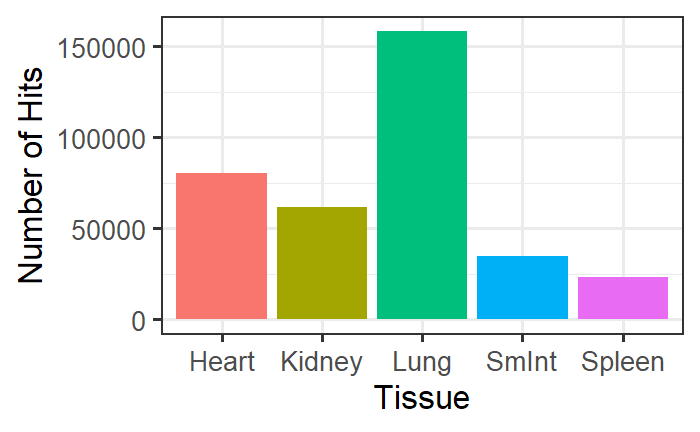

```r
plot
dev.off()
```

```r
plot <- hits %>%
  select(Uniprot_Id, Tissue) %>%
  unique() %>%
  ggplot(aes(x = Tissue, fill = Tissue)) +
    geom_bar() +
    labs(y = "Number of Proteins") +
  theme_bw(base_size = 25) +
  theme(legend.position = "none")
plot
pdf(file = "figures/ProteinIDs_byTissue.pdf")
```

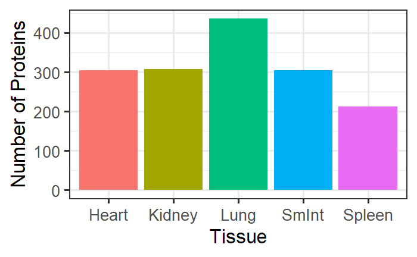

```r
plot
dev.off()
```

```r
plot <- hits %>%
  select(PFR, Tissue) %>%
  unique() %>%
  ggplot(aes(x = Tissue, fill = Tissue)) +
    geom_bar() +
    labs(y = "Number of PFRs") +
  theme_bw(base_size = 25) +
  theme(legend.position = "none")
plot
pdf(file = "figures/PFRIDs_byTissue.pdf")
```

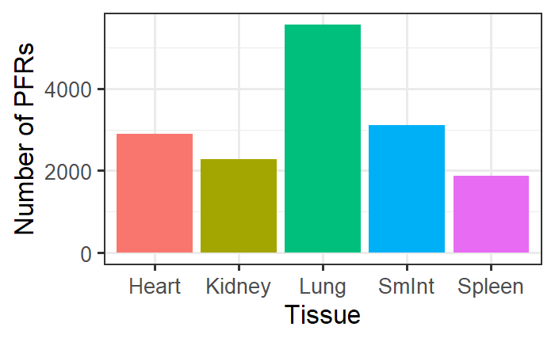

```r
plot
dev.off()
```

## Proteome Coverage from Each Tissue

```r
source("proteome_coverage.R")

get_coverage <- function(df) {
  df <- df %>% select(Accession, Start_Index, End_Index) %>%
    unique()
  y <- lapply(split(df[2:3], df$Accession), proteome_coverage)
  return(sum(unlist(y)))
}

df <- hits %>%
  select(Tissue, Accession, Start_Index, End_Index)
x <- lapply(split(df[2:4], df$Tissue), get_coverage)
x <- as.data.frame(x) %>%
  pivot_longer(everything(), names_to = "Tissue", values_to = "Coverage") %>%
  mutate(Percent_Coverage = Coverage/human_proteome_aa)

plot <- ggplot(x, aes(x = Tissue, y = Coverage, fill = Tissue)) +
  geom_col() +
  theme_bw(base_size = 25) +
  labs(y = "Proteome Coverage (amino acids)") +
  theme(legend.position = "none")
plot
pdf(file = "figures/ProteomCoverage_byTissue.pdf")
```

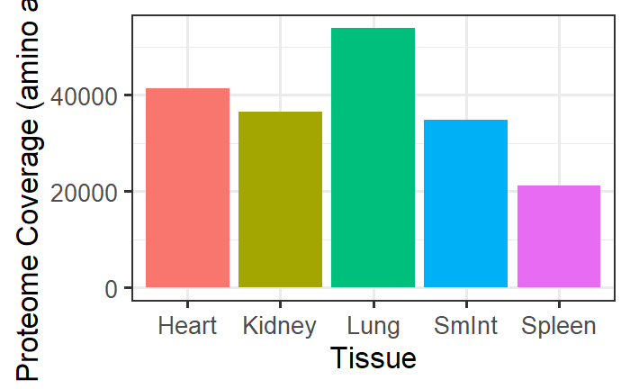

```r
plot
dev.off()
```

```r
plot <- ggplot(x, aes(x = Tissue, y = Percent_Coverage*100, fill = Tissue)) +
  geom_col() +
  theme_bw(base_size = 25) +
  labs(y = "Percent Proteome Coverage") +
  theme(legend.position = "none")
plot
pdf(file = "figures/PercentProteomCoverage_byTissue.pdf")
```

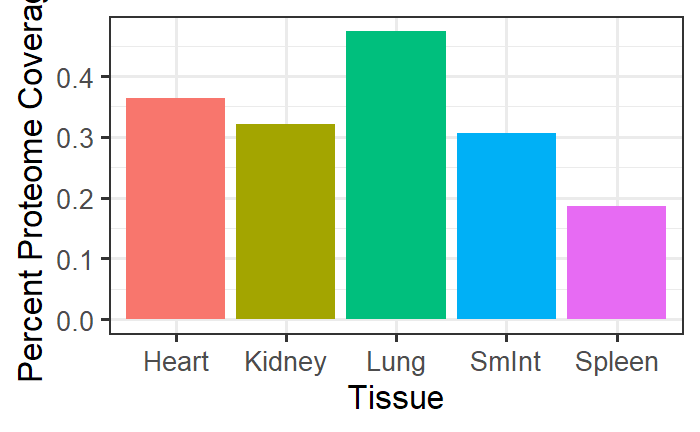

```r
plot
dev.off()
```

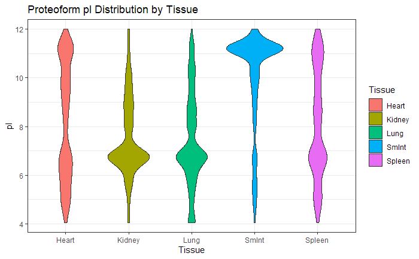

```r
# Overall distribution of proteoform physiochemical properties

# pI
hits %>%
  select(PFR, pI, Tissue) %>%
  unique() %>%
  ggplot(aes(y = pI, x = Tissue, fill = Tissue)) +
    geom_violin() +
    theme_bw() +
    labs(title = "Proteoform pI Distribution by Tissue")
```

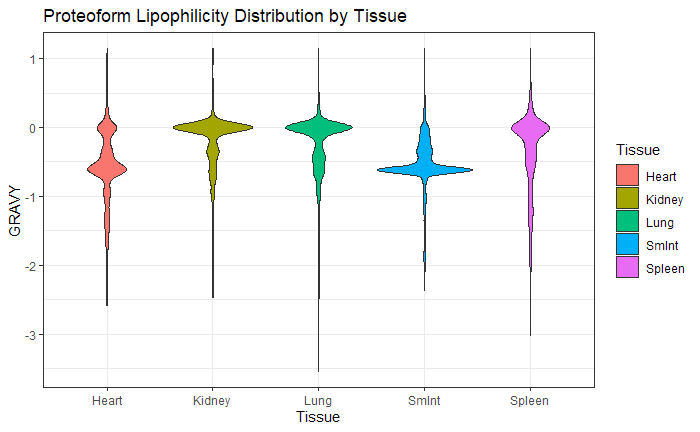

```r
# Lipophilicity
hits %>%
  select(PFR, GRAVY, Tissue) %>%
  unique() %>%
  ggplot(aes(y = GRAVY, x = Tissue, fill = Tissue)) +
    geom_violin() +
    theme_bw() +
    labs(title = "Proteoform Lipophilicity Distribution by Tissue")
```

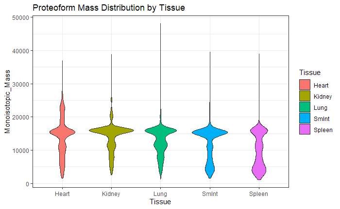

```r
# Mass
hits %>%
  select(PFR, Monoisotopic_Mass, Tissue) %>%
  unique() %>%
  ggplot(aes(y = Monoisotopic_Mass, x = Tissue, fill = Tissue)) +
    geom_violin() +
    theme_bw() +
    labs(title = "Proteoform Mass Distribution by Tissue")
```

```r
NA
NA
NA
```

# PTM Frequency

```r
# Many of the PTMs that are actually very specific (e.g. phosphoserine)
# We instead want to group all phosphorylations together
# ptm_map relates specific PTMs to their more general PSI-MOD entries
ptm_map <- read.csv(file = "data/ptm_mapping.csv")
colnames(ptm_map)[1] <- "Modification_Codes"

df <- hits %>%
  filter(Modification_Codes == "" | num_fragments > 2 ) %>%
  select(PFR, Tissue, Modification_Codes) %>%
  unique() %>%
  separate_rows(Modification_Codes, sep="\\|") %>%
  mutate(Modification_Codes = str_split(Modification_Codes, pattern="@", simplify = TRUE)[,1])

# Now count the number of each PTM in PFRs
# If a PFR contains the same PTM multiple times, it is counted multiple times
ptm_counts <- merge(df, ptm_map)%>%
  select(General.Description, Tissue) %>%
  ungroup() %>%
  group_by(General.Description, Tissue) %>%
  summarise(Count = n(), .groups = "drop") %>%
  arrange(-Count)

# The Chi-squared test is not accurate when there are fewer than 5 observations
# so I'll remove any PTMs that were seen fewer than 5 times.
ptm_counts <- ptm_counts %>%
  pivot_wider(names_from = Tissue, values_from = Count, values_fill = 0)

# The base Chi-squared test function accepts a matrix with named rows as input
mtx <- ptm_counts %>%
  select(-General.Description) %>%
  as.matrix
rownames(mtx) <- ptm_counts$General.Description

# Let's calculate the rate of observing each mod
ptm_counts <- ptm_counts %>%
  mutate(Lung_rate = Lung / sum(ptm_counts$Lung)) %>%
  mutate(Heart_rate = Heart / sum(ptm_counts$Heart)) %>%
  mutate(Kidney_rate = Kidney / sum(ptm_counts$Kidney)) %>%
  mutate(Spleen_rate = Spleen / sum(ptm_counts$Spleen)) %>%
  mutate(SmInt_rate = SmInt / sum(ptm_counts$SmInt))

# Chi-squared
test <- chisq.test(mtx)
test
```

```
    Pearson's Chi-squared test

data:  mtx
X-squared = 415.74, df = 48, p-value < 2.2e-16
```

```r
# Compare the expected distribution to the actual distribution
ptm_counts$Lung_expected <- test$expected[,"Lung"]
ptm_counts$Heart_expected <- test$expected[,"Heart"]
ptm_counts$Kidney_expected <- test$expected[,"Kidney"]
ptm_counts$Spleen_expected <- test$expected[,"Spleen"]
ptm_counts$SmInt_expected <- test$expected[,"SmInt"]
ptm_counts
```

| General.Description | Lung | Heart | SmInt | Spleen | Kidney | Lung_rate | Heart_rate | Kidney_rate | Spleen_rate | SmInt_rate | Lung_expected | Heart_expected | Kidney_expected | Spleen_expected | SmInt_expected |
| --- | --- | --- | --- | --- | --- | --- | --- | --- | --- | --- | --- | --- | --- | --- | --- |
| None | 1533 | 1128 | 1108 | 960 | 645 | 0.7348993289 | 0.820960699 | 0.829048843 | 0.7855973813 | 0.8312078020 | 1650.2523186 | 1086.9830708 | 615.4824084 | 966.7345797 | 1054.5476226 |
| monoacetylated residue | 144 | 74 | 41 | 57 | 54 | 0.0690316395 | 0.053857351 | 0.069408740 | 0.0466448445 | 0.0307576894 | 113.6199028 | 74.8388047 | 42.3759753 | 66.5596938 | 72.6056234 |
| half cystine | 143 | 37 | 72 | 17 | 25 | 0.0685522531 | 0.026928675 | 0.032133676 | 0.0139116203 | 0.0540135034 | 90.2817606 | 59.4665096 | 33.6717209 | 52.8879729 | 57.6920359 |
| phosphorylated residue | 86 | 80 | 23 | 32 | 21 | 0.0412272291 | 0.058224163 | 0.026992288 | 0.0261865794 | 0.0172543136 | 74.3135581 | 48.9486236 | 27.7161784 | 43.5336376 | 47.4880024 |
| monomethylated residue | 65 | 11 | 39 | 73 | 9 | 0.0311601151 | 0.008005822 | 0.011568123 | 0.0597381342 | 0.0292573143 | 60.4949212 | 39.8466068 | 22.5623436 | 35.4385397 | 38.6575887 |
| monohydroxylated residue | 29 | 1 | 4 | 48 | 0 | 0.0139022052 | 0.000727802 | 0.000000000 | 0.0392798691 | 0.0030007502 | 25.1806271 | 16.5858972 | 9.3914324 | 14.7510673 | 16.0909760 |
| dimethylated residue | 27 | 6 | 39 | 12 | 5 | 0.0129434324 | 0.004366812 | 0.006426735 | 0.0098199673 | 0.0292573143 | 27.3301928 | 18.0017665 | 10.1931400 | 16.0103047 | 17.4645959 |
| nitrosylated residue | 38 | 17 | 2 | 18 | 14 | 0.0182166826 | 0.012372635 | 0.017994859 | 0.0147299509 | 0.0015003751 | 27.3301928 | 18.0017665 | 10.1931400 | 16.0103047 | 17.4645959 |
| trimethylated protonated-residue | 13 | 12 | 3 | 4 | 4 | 0.0062320230 | 0.008733624 | 0.005141388 | 0.0032733224 | 0.0022505626 | 11.0549095 | 7.2816134 | 4.1230679 | 6.4760783 | 7.0643309 |
| deamidated L-asparagine | 6 | 2 | 1 | 1 | 0 | 0.0028763183 | 0.001455604 | 0.000000000 | 0.0008183306 | 0.0007501875 | 3.0708082 | 2.0226704 | 1.1452966 | 1.7989106 | 1.9623141 |

[output cut: 3 more lines]

[output not shown]